# Imputation methods comparison

In a first part, we perform the analysis with the traumabase data. We measure prediction performance using two different metrics but in both cases all methods (including the simplest one, imputation by the mean) seem to perform similarly. One thing that could explain this is the fact that the missingness is not completely at random: very often if one record is missing in a line, a lot of other values are missing in that line. This may mean that lines with missing data become very hard to impute, whichever method is used. Another option is that this correlation in missingness means that when data is missing this is actually a useful information and should be used in the prediction.

A good next step would be to make similar comparisons on simulated datasets with different levels of corrlelation in the dataset/in the missingness structure to see how our observasions hold on well controlled data.

# With Trauma data

## Preparation

### Imports

```r
## Imports
library(tidyverse)
library(cowplot)
library(verification)
library(caret)
library(mice)
library(Amelia)
library(missForest)
library(missMDA)
library(MLmetrics)
library(pander)


# Custom imports
aux.folder = '../../auxiliary/'
source(paste(aux.folder,'dataloaders.R',sep=''), chdir = T)
source(paste(aux.folder,'imputation_methods.R',sep=''), chdir = T)
source(paste(aux.folder,'generate_missing.R',sep=''), chdir = T)
source(paste(aux.folder,'prediction_methods.R',sep=''), chdir = T)
data_folder = '../../../Data/'
```

### Load data

```r
dataset = 'trauma'
max_rows = NULL
seed = 5
train_size = 0.2

# Load and format the dataset
dat = loader(dataset, max_rows, seed)
```

```
## [1] "Loading trauma data..."
## [1] "Imported  15  numerical variables ( 13.5765101539258 % missing entries), and  23  categorical variables ( 24.0724806397732 % missing entries)."
## [1] "Done (5154 rows)."
```

```r
y = dat$y
X = dat$X_numeric

keepCols = c("Age", "Glasgow.moteur.initial", "FC.max", "Hemocue.init",
                 "Remplissage.total.cristalloides","Remplissage.total.colloides", "SD.min", "SD.SMUR")
X = X %>% dplyr::select(one_of(keepCols))
colnames(X) = c('Age', 'Glasgow', 'FC', 'Hemo', 'Cristall', 'Colloides', 'SD.min', 'SD.SMUR')

set.seed(seed)
inTraining = createDataPartition(y, p=train_size, list=FALSE)

print('Correlation of the missingness of the variables')
```

```
## [1] "Correlation of the missingness of the variables"
```

```r
pander(cor(is.na(X)))
```

Table continues below

|  | Age | Glasgow | FC | Hemo | Cristall |
| --- | --- | --- | --- | --- | --- |
| **Age** | 1 | 0.01521 | -0.005446 | -0.009184 | 0.03786 |
| **Glasgow** | 0.01521 | 1 | 0.0323 | 0.02418 | 0.1775 |
| **FC** | -0.005446 | 0.0323 | 1 | 0.2266 | 0.1639 |
| **Hemo** | -0.009184 | 0.02418 | 0.2266 | 1 | 0.0697 |
| **Cristall** | 0.03786 | 0.1775 | 0.1639 | 0.0697 | 1 |
| **Colloides** | 0.02975 | 0.1682 | 0.1377 | 0.06451 | 0.761 |
| **SD.min** | -0.005838 | 0.05393 | 0.6373 | 0.207 | 0.1423 |
| **SD.SMUR** | 0.02295 | 0.08176 | 0.01832 | -0.03782 | 0.1576 |

|  | Colloides | SD.min | SD.SMUR |
| --- | --- | --- | --- |
| **Age** | 0.02975 | -0.005838 | 0.02295 |
| **Glasgow** | 0.1682 | 0.05393 | 0.08176 |
| **FC** | 0.1377 | 0.6373 | 0.01832 |
| **Hemo** | 0.06451 | 0.207 | -0.03782 |
| **Cristall** | 0.761 | 0.1423 | 0.1576 |
| **Colloides** | 1 | 0.1206 | 0.2046 |
| **SD.min** | 0.1206 | 1 | 0.06319 |
| **SD.SMUR** | 0.2046 | 0.06319 | 1 |

## Imputations

```r
X_complete = X[rowSums(is.na(X %>% dplyr::select(SD.SMUR, Hemo)))==0,]

filled.datasets = list()
filled.datasets[['mice.pmm']] = mice::complete(mice(X, m=1, method='pmm', printFlag = F))
filled.datasets[['mice.norm']] = mice::complete(mice(X, m=1, method='norm', printFlag = F))
filled.datasets[['mean']] = mice::complete(mice(X, m=1, method='mean', printFlag = F))
filled.datasets[['mipca']] = MIPCA(X, ncp=3, nboot=1)$res.MI[[1]]
filled.datasets[['amelia']] = amelia(X, m=1, noms=c(), p2s=0, parallel = 'multicore', ncpus = 4)$imputations$imp1
##filled.datasets[['MF']] = missForest(X)$ximp
filled.datasets[['MF']] = filled.datasets[['amelia']]
filled.datasets[['MVN']] = MVN_imp_single(X)

m=20
MI_imputation = mice(X,m=m, method='norm', printFlag = F)
```

We plot a comparison of the distribution of two variables (chosen arbitrarily among those with many missing values) depending on the imputation method. The ‘complete’ dataset is made only of the points where there are no missing values. It is included as a reference.

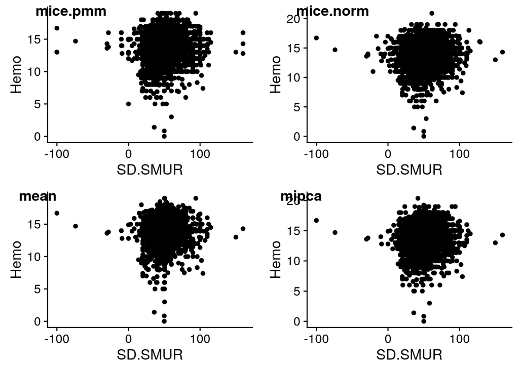

```r
plot.mice.pmm = ggplot(filled.datasets$mice.pmm) + aes(x=SD.SMUR, y=Hemo) + geom_point() #+ geom_hline(yintercept = mean(X$Hemo, na.rm=T), color='red') + geom_vline(xintercept = mean(X$SD.SMUR, na.rm=T), color='red')
plot.mice.norm = ggplot(filled.datasets$mice.norm) + aes(x=SD.SMUR, y=Hemo) + geom_point()
plot.mean = ggplot(filled.datasets$mean) + aes(x=SD.SMUR, y=Hemo) + geom_point()
plot.MVN = ggplot(filled.datasets$MVN) + aes(x=SD.SMUR, y=Hemo) + geom_point()
plot.mipca = ggplot(filled.datasets$mipca) + aes(x=SD.SMUR, y=Hemo) + geom_point()
plot.amelia = ggplot(filled.datasets$amelia) + aes(x=SD.SMUR, y=Hemo) + geom_point()
plot.MF = ggplot(filled.datasets$MF) + aes(x=SD.SMUR, y=Hemo) + geom_point()
plot.complete = ggplot(X_complete) + aes(x=SD.SMUR, y=Hemo) + geom_point()

plot_grid(plot.mice.pmm, plot.mice.norm, plot.mean, plot.mipca, labels=c('mice.pmm', 'mice.norm', 'mean', 'mipca'), ncol=2)
```

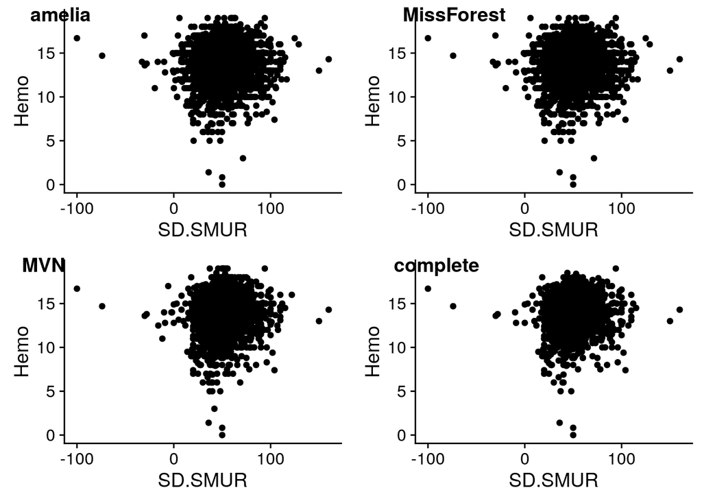

```r
plot_grid(plot.amelia, plot.MF, plot.MVN, plot.complete, labels=c('amelia', 'MissForest', 'MVN', 'complete'), ncol=2)
```

### Predictions

```r
preds = list()
for(n in names(filled.datasets)){
  X_filled = filled.datasets[[n]]
  dat_train = cbind(y,X_filled)[inTraining,]
  #fitControl = trainControl(method = "none", classProbs = TRUE)
  #fittedM = train(X_filled[inTraining,], y[inTraining])
  #preds[[n]] = predict(fittedM, X_filled[-inTraining,], type='prob')[,2]
  fittedM = glm(y ~ .,family=binomial(link='logit'),data=dat_train)
  preds[[n]] = predict(fittedM, X_filled[-inTraining,], type='response')
}

pred.MI = matrix(NA,nrow=nrow(X_filled)-length(inTraining), ncol=m)
for(i in 1:20){
  X_filled = mice::complete(MI_imputation, action=i)
  dat_train = cbind(y,X_filled)[inTraining,]
  fittedM = glm(y ~ .,family=binomial(link='logit'),data=dat_train)
  pred.MI[,i] = predict(fittedM, X_filled[-inTraining,], type='link')
}
o = rowMeans(pred.MI)
preds[['MI']] = exp(o)/(1+exp(o))

preds.SAEM = saem_prediction(X, y, seed=seed, spl=inTraining, printevery=50)
```

```
## [1] "Predicting response using SAEM logistic regression on 50% of the data as training set..."
## [1] "Existing train/test split provided. Ignoring train_size parameter."
## iteration = 50 beta = -0.9341657 0.01864833 -0.05064706 0.02436026 -0.2338933 0.0008775599 0.00272234 -0.03840501 -0.01464941
## Distance from estimator from last iter = 0.009041773
## iteration = 100 beta = -1.16172 0.01786919 -0.05423618 0.02348333 -0.2240661 0.0009219522 0.002538642 -0.03987459 -0.008499974
## Distance from estimator from last iter = 5.427288e-05
```

```r
preds[['SAEM']] = preds.SAEM$y_pred[-inTraining]
```

### Evaluation

```r
y_test = as.numeric(y[-inTraining]) -1
preds = as.data.frame(preds)
print('Correlation of the prediction on positive cases')
```

```
## [1] "Correlation of the prediction on positive cases"
```

```r
pander(cor(preds[y_test==1,]))
```

Table continues below

|  | mice.pmm | mice.norm | mean | mipca | amelia | MF |
| --- | --- | --- | --- | --- | --- | --- |
| **mice.pmm** | 1 | 0.9315 | 0.9377 | 0.9355 | 0.9522 | 0.9522 |
| **mice.norm** | 0.9315 | 1 | 0.9782 | 0.9458 | 0.9686 | 0.9686 |
| **mean** | 0.9377 | 0.9782 | 1 | 0.9546 | 0.962 | 0.962 |
| **mipca** | 0.9355 | 0.9458 | 0.9546 | 1 | 0.9504 | 0.9504 |
| **amelia** | 0.9522 | 0.9686 | 0.962 | 0.9504 | 1 | 1 |
| **MF** | 0.9522 | 0.9686 | 0.962 | 0.9504 | 1 | 1 |
| **MVN** | 0.9521 | 0.9816 | 0.9892 | 0.9731 | 0.9812 | 0.9812 |
| **MI** | 0.9546 | 0.9824 | 0.9882 | 0.9734 | 0.9828 | 0.9828 |
| **SAEM** | 0.9533 | 0.9798 | 0.9871 | 0.9734 | 0.9819 | 0.9819 |

|  | MVN | MI | SAEM |
| --- | --- | --- | --- |
| **mice.pmm** | 0.9521 | 0.9546 | 0.9533 |
| **mice.norm** | 0.9816 | 0.9824 | 0.9798 |
| **mean** | 0.9892 | 0.9882 | 0.9871 |
| **mipca** | 0.9731 | 0.9734 | 0.9734 |
| **amelia** | 0.9812 | 0.9828 | 0.9819 |
| **MF** | 0.9812 | 0.9828 | 0.9819 |
| **MVN** | 1 | 0.9983 | 0.9993 |
| **MI** | 0.9983 | 1 | 0.9977 |
| **SAEM** | 0.9993 | 0.9977 | 1 |

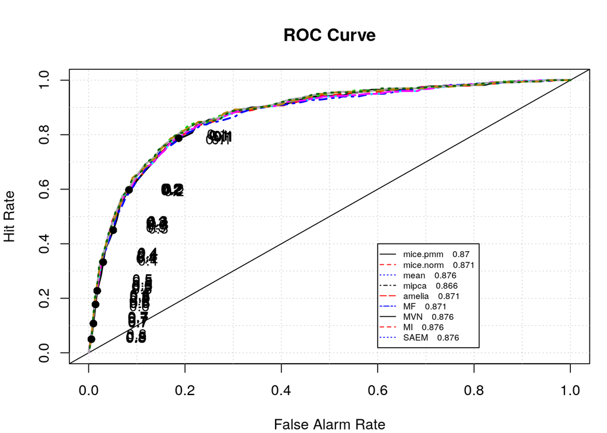

```r
roc.plot(y_test, preds, legend=T, leg.text=colnames(preds))
```

```r
separation = matrix(NA,nrow=2, ncol=length(preds)+1)
for(i in 1:(length(preds))){
  thresh = 0.1
  conf = confusionMatrix(factor(as.integer(preds[,i]>thresh)),as.factor(y_test), positive='1')
  separation[1,i] = conf$table[2,2]
  separation[2,i] = conf$table[2,1]
}

separation[1,length(preds)+1] = sum(y_test)
separation[2,length(preds)+1] = 0
colnames(separation) = c(names(preds), 'Ground truth')
rownames(separation) = c('True positives','False positives')
print('Confusion matrix for a fixed threshold (0.1)')
```

```
## [1] "Confusion matrix for a fixed threshold (0.1)"
```

```r
pander(data.frame(separation))
```

Table continues below

|  | mice.pmm | mice.norm | mean | mipca | amelia | MF | MVN |
| --- | --- | --- | --- | --- | --- | --- | --- |
| **True positives** | 315 | 313 | 317 | 310 | 316 | 316 | 313 |
| **False positives** | 674 | 688 | 633 | 674 | 683 | 683 | 649 |

|  | MI | SAEM | Ground.truth |
| --- | --- | --- | --- |
| **True positives** | 317 | 310 | 400 |
| **False positives** | 649 | 628 | 0 |

## Comparison with doctors

```r
discordance = dat$X_category$Discordance
pred.positive = (preds>0.1) %>% as.data.frame()
pred.positive$discordance = discordance[-inTraining]
pred.positive$true = y_test

table(pred.positive[c('SAEM', 'discordance')])
```

```
##        discordance
## SAEM     MGA PDAC PDSC  PGA
##   FALSE   71   23 2854   58
##   TRUE    58  156  525  119
```

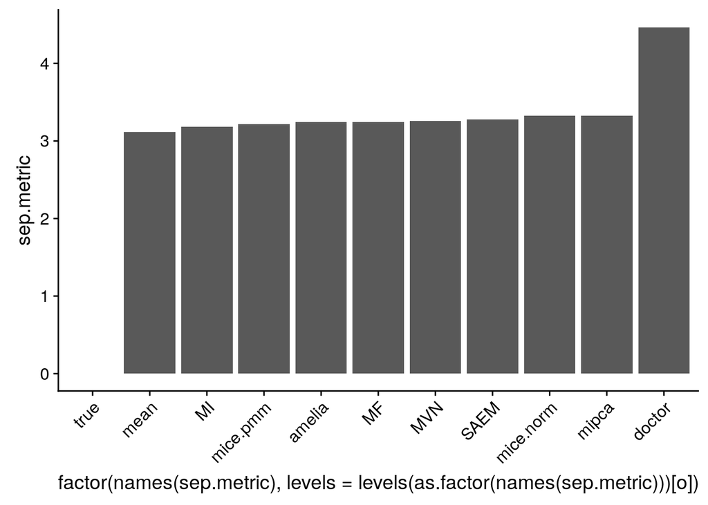

```r
pred.doctor = as.character(discordance)
pred.doctor[discordance %in% c('PDSC','PGA')] = F
pred.doctor[discordance %in% c('PDAC', 'MGA')] = T

pred.positive$discordance = NULL
pred.positive$doctor = pred.doctor[-inTraining]
pred.positive = pred.positive[!is.na(pred.positive$doctor),]

pred.positive[pred.positive==T] = 0.9
pred.positive[pred.positive==F] = 0.1
sep.metric = sapply(pred.positive,function(x) metric_best_separation(y_pred =x, y_true =pred.positive$true, positive_weighting = 10)$val)
o = order(sep.metric[order(names(sep.metric))])
ggplot() + aes(x=factor(names(sep.metric),levels=levels(as.factor(names(sep.metric)))[o]),
               y=sep.metric) + geom_bar(stat='identity') +
  theme(axis.text.x = element_text(angle = 45, hjust = 1))
```

# With Abalone data (and added MCAR values)

### Load data

```r
dataset = 'abalone'
prop.missing = 0.2

# Load and format the dataset
dat = loader(dataset, max_rows, seed)
```

```
## [1] "Loading abalone data..."
## [1] "Imported  7  numerical variables ( 0 % missing entries), and  1  categorical variables ( 0 % missing entries)."
## [1] "Done (4177 rows)."
```

```r
y = dat$y
X = dat$X_numeric

y = y[X$Height<0.4]
X = X[X$Height<0.4,]

set.seed(seed)
inTraining = createDataPartition(y, p=train_size, list=FALSE)

X_complete = X
X = MCAR(X, prop.missing)
```

```
## [1] "Adding 20% missing observations completely at random."
## [1] "New proportion of missing data: 20.1505560307956%."
## [1] "Done."
```

## Imputations

```r
filled.datasets = list()
filled.datasets[['mice.pmm']] = mice::complete(mice(X, m=1, method='pmm', printFlag = F))
filled.datasets[['mice.norm']] = mice::complete(mice(X, m=1, method='norm', printFlag = F))
filled.datasets[['mean']] = mice::complete(mice(X, m=1, method='mean', printFlag = F))
filled.datasets[['mipca']] = MIPCA(X, ncp=3, nboot=1)$res.MI[[1]]
filled.datasets[['amelia']] = amelia(X, m=1, noms=c(), p2s=0, parallel = 'multicore', ncpus = 4)$imputations$imp1
filled.datasets[['MF']] = missForest(X)$ximp
filled.datasets[['MVN']] = MVN_imp_single(X)

MI_imputation = mice(X,m=m, method='norm', printFlag = F)
```

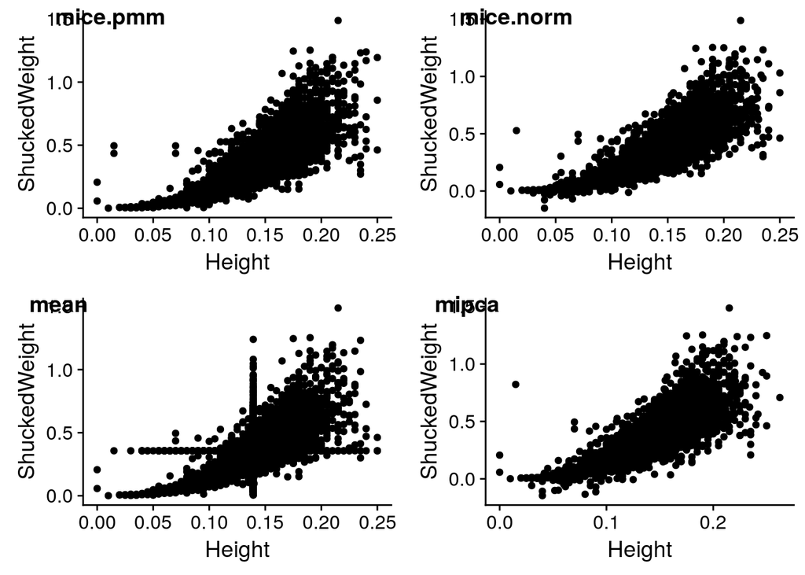

```r
plot.mice.pmm = ggplot(filled.datasets$mice.pmm) + aes(x=Height, y=ShuckedWeight) + geom_point() #+ geom_hline(yintercept = mean(X$Hemo, na.rm=T), color='red') + geom_vline(xintercept = mean(X$SD.SMUR, na.rm=T), color='red')
plot.mice.norm = ggplot(filled.datasets$mice.norm) + aes(x=Height, y=ShuckedWeight) + geom_point()
plot.mean = ggplot(filled.datasets$mean) + aes(x=Height, y=ShuckedWeight) + geom_point()
plot.MVN = ggplot(filled.datasets$MVN) + aes(x=Height, y=ShuckedWeight) + geom_point()
plot.mipca = ggplot(filled.datasets$mipca) + aes(x=Height, y=ShuckedWeight) + geom_point()
plot.amelia = ggplot(filled.datasets$amelia) + aes(x=Height, y=ShuckedWeight) + geom_point()
plot.MF = ggplot(filled.datasets$MF) + aes(x=Height, y=ShuckedWeight) + geom_point()
plot.complete = ggplot(X_complete) + aes(x=Height, y=ShuckedWeight) + geom_point()

plot_grid(plot.mice.pmm, plot.mice.norm, plot.mean, plot.mipca, labels=c('mice.pmm', 'mice.norm', 'mean', 'mipca'), ncol=2)
```

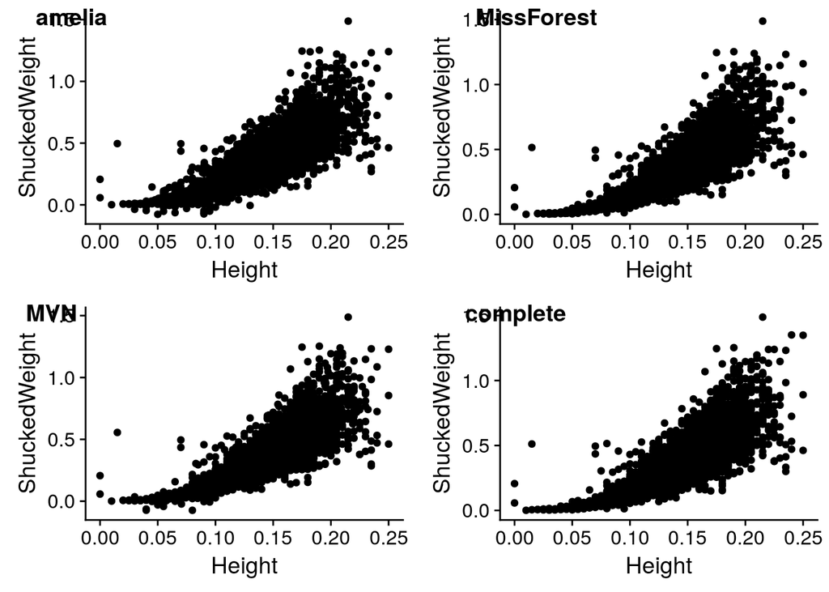

```r
plot_grid(plot.amelia, plot.MF, plot.MVN, plot.complete, labels=c('amelia', 'MissForest', 'MVN', 'complete'), ncol=2)
```

### Predictions

```r
preds = list()
for(n in names(filled.datasets)){
  print(n)
  X_filled = filled.datasets[[n]]
  dat_train = cbind(y,X_filled)[inTraining,]
  #fitControl = trainControl(method = "none")
  #fittedM = train(X_filled[inTraining,], y[inTraining])
  #preds[[n]] = predict(fittedM, X_filled[-inTraining,])
  fittedM = lm(y ~ .,data=dat_train)
  preds[[n]] = predict(fittedM, X_filled[-inTraining,], type='response')
}
```

```
## [1] "mice.pmm"
## [1] "mice.norm"
## [1] "mean"
## [1] "mipca"
## [1] "amelia"
## [1] "MF"
## [1] "MVN"
```

```r
pred.MI = matrix(NA,nrow=nrow(X_filled)-length(inTraining), ncol=m)
for(i in 1:20){
  X_filled = mice::complete(MI_imputation, action=i)
  dat_train = cbind(y,X_filled)[inTraining,]
  fittedM = lm(y ~ .,data=dat_train)
  pred.MI[,i] = predict(fittedM, X_filled[-inTraining,], type='response')
}

preds[['MI']] = rowMeans(pred.MI)
```

### Evaluation

```r
y_test = as.numeric(y[-inTraining]) -1
preds = as.data.frame(preds)
print('Correlation between the predictions')
```

```
## [1] "Correlation between the predictions"
```

```r
pander(cor(preds))
```

Table continues below

|  | mice.pmm | mice.norm | mean | mipca | amelia | MF |
| --- | --- | --- | --- | --- | --- | --- |
| **mice.pmm** | 1 | 0.9642 | 0.8862 | 0.9526 | 0.9609 | 0.9759 |
| **mice.norm** | 0.9642 | 1 | 0.8878 | 0.9547 | 0.962 | 0.973 |
| **mean** | 0.8862 | 0.8878 | 1 | 0.895 | 0.8824 | 0.8839 |
| **mipca** | 0.9526 | 0.9547 | 0.895 | 1 | 0.9511 | 0.965 |
| **amelia** | 0.9609 | 0.962 | 0.8824 | 0.9511 | 1 | 0.9705 |
| **MF** | 0.9759 | 0.973 | 0.8839 | 0.965 | 0.9705 | 1 |
| **MVN** | 0.981 | 0.9789 | 0.8854 | 0.9656 | 0.9771 | 0.9917 |
| **MI** | 0.9819 | 0.9801 | 0.9005 | 0.9693 | 0.9781 | 0.9895 |

|  | MVN | MI |
| --- | --- | --- |
| **mice.pmm** | 0.981 | 0.9819 |
| **mice.norm** | 0.9789 | 0.9801 |
| **mean** | 0.8854 | 0.9005 |
| **mipca** | 0.9656 | 0.9693 |
| **amelia** | 0.9771 | 0.9781 |
| **MF** | 0.9917 | 0.9895 |
| **MVN** | 1 | 0.997 |
| **MI** | 0.997 | 1 |

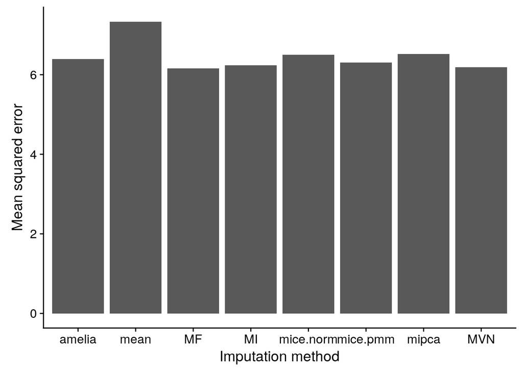

```r
MSEs = sapply(preds, function(x) MSE(x, y_test))
ggplot() + aes(x=names(MSEs), y=MSEs) + geom_bar(stat='identity') + xlab("Imputation method") + ylab('Mean squared error')
```

```r
sort(MSEs)
```

```
##        MF       MVN        MI  mice.pmm    amelia mice.norm     mipca
##  6.157348  6.184045  6.234638  6.307175  6.395229  6.502070  6.523427
##      mean
##  7.328891
```